# 19_B_ESmoothing_Model_Selection

# References

1. Hyndman, R.J., & Athanasopoulos, G. (2021). *Forecasting: principles and practice* (3rd ed.), sections 8.5 to 8.7. https://otexts.com/fpp3/
2. Hyndman, R. J., Koehler, A. B., Ord, J. K., & Snyder, R. D. (2008). *Forecasting with exponential smoothing: The state space approach*. Springer-Verlag.
3. Akaike, H. (1974). A new look at the statistical model identification. *IEEE Transactions on Automatic Control*, 19, 716-723.

This notebook is not original material. It expands reference 1 with the professor’s notes. It is the source of the notebook distributed in 2025 as `06_5_B`, rewritten for this course.

# Libraries

```r
library(fpp3)
```

# The ETS statistical framework and model selection

## Minimizing the SSE vs maximizing the likelihood

Writing exponential smoothing as a statistical model (fpp3 8.5) makes it possible to compute the **likelihood** of a model: how probable the observed data are if that model generated them. The likelihood is a joint probability density, evaluated at the data. A larger likelihood means a model that fits the data better. The handwritten primer `19_A_MLE_Informal_Intro.pdf` in this folder builds the idea from the normal distribution.

- **For an additive error model**, maximizing the likelihood (assuming normally distributed errors) gives the same parameters as minimizing the sum of squared errors, which is what Sessions 15 to 18 did.
- **For a multiplicative error model**, the two give different results. Maximizing the likelihood is what `ETS()` does in both cases.

## Information criteria vs the likelihood

Information criteria combine the likelihood with a penalty for the number of parameters. Maximizing the likelihood alone always favors the model with more parameters, because extra parameters can only help the fit to the training data. The penalty compensates for that, and protects against overfitting.

## Information criteria vs cross-validation

The information criteria used here are $AIC$, $AIC_c$ and $BIC$. Because they are built on the likelihood, they can only compare models **of the same class, fitted to the same response variable** (after any transformation). They can choose an ETS model among ETS models; they cannot compare an ETS model with a model of another class, such as the ARIMA models of the follow-up course, whose likelihood is computed differently. They also cannot compare a model of `y` with a model of `log(y)`.

To compare models of different classes, or of differently transformed data, use cross-validation (Session 14).

# The information criteria

## AIC: Akaike’s Information Criterion

For ETS models:

$$\text{AIC} = -2\log(L) + 2k$$

- $L$ is the likelihood of the model.
- $k$ is the total number of parameters and initial states that have been estimated, **including the residual variance**. It measures the complexity of the model.

The lower the AIC, the better. The first term falls as the fit improves; the second rises with every parameter.

## AICc: the bias-corrected AIC

For small samples (small $T$, the length of the series), the AIC tends to choose models with too many parameters. The corrected version works better:

$$\text{AIC}_{\text{c}} = \text{AIC} + \frac{2k(k+1)}{T-k-1}$$

As with the AIC, lower is better. `ETS()` uses the $AIC_c$ by default when it chooses a model.

## BIC: the Bayesian Information Criterion

$$\text{BIC} = \text{AIC} + k[\log(T)-2]$$

The BIC penalizes each parameter more heavily than the AIC once $T$ is 8 or more ($\log T > 2$), so it chooses either the same model as the AIC or one with fewer parameters.

## Model combinations that are excluded

Three combinations of (Error, Trend, Season) can be numerically unstable, because their state equations divide by values that may be close to zero:

- $ETS(A, N, M)$
- $ETS(A, A, M)$
- $ETS(A, Ad, M)$

They are not considered when `ETS()` chooses a model. With trends N, A and Ad, errors A and M, and seasons N, A and M, that leaves 15 of the 18 combinations.

## Models with multiplicative errors

- Useful when the data are **strictly positive**.
- Numerically unstable when the data contain zeros or negative values, so `ETS()` does not consider multiplicative errors for a series that is not strictly positive.

Session 11’s transformations, such as $\log(1+x)$ for data with zeros, are one way around this. Remember that a transformation changes the interpretation of the model and the shape of the forecast distribution, as Session 12 showed.

## Residuals and multiplicative errors

With multiplicative errors, the residuals and the innovation residuals differ, even without a transformation. `augment()` returns both:

- **Response residuals** (`.resid`): $\hat{e}_t = y_t - \hat{y}_{t|t-1}$.
- **Innovation residuals** (`.innov`):
  - additive error model: $\hat{\varepsilon}_t = y_t - \hat{y}_{t|t-1}$;
  - multiplicative error model: $\hat{\varepsilon}_t = \dfrac{y_t - \hat{y}_{t|t-1}}{\hat{y}_{t|t-1}}$, a relative error.

So for a multiplicative error model, run Session 9’s residual diagnostics on `.innov`, which is the error the model assumes to be white noise.

# Automatic ETS model selection

## How to ask `ETS()` to choose

When the formula does not fix a component, `ETS()` tries every allowed option for it and keeps the model with the lowest $AIC_c$. With no specials at all, `ETS(y)`, it searches all 15 combinations.

## Example 1: national populations

Automatic models for the population of every country in `global_economy`. One country has missing values, which `ETS()` does not accept, so it raises a warning and fits nothing for that country.

```r
fit <- global_economy |>
  mutate(Pop = Population / 1e6) |>
  model(ets = ETS(Pop))

fit
```

```
# A mable: 263 x 2
# Key:     Country [263]
   Country                      ets
   <fct>                    <model>
 1 Afghanistan         <ETS(A,A,N)>
 2 Albania             <ETS(M,A,N)>
 3 Algeria             <ETS(M,A,N)>
 4 American Samoa      <ETS(M,A,N)>
 5 Andorra             <ETS(M,A,N)>
 6 Angola              <ETS(M,A,N)>
 7 Antigua and Barbuda <ETS(M,A,N)>
 8 Arab World          <ETS(M,A,N)>
 9 Argentina           <ETS(A,A,N)>
10 Armenia             <ETS(M,A,N)>
# ℹ 253 more rows
```

`glance()` gives one row of summary statistics per model:

```r
fit |> glance()
```

```
# A tibble: 263 × 10
   Country  .model  sigma2 log_lik    AIC   AICc     BIC     MSE    AMSE     MAE
   <fct>    <chr>    <dbl>   <dbl>  <dbl>  <dbl>   <dbl>   <dbl>   <dbl>   <dbl>
 1 Afghani… ets    1.17e-2    13.3  -16.6  -15.4   -6.30 1.09e-2 1.49e-1 8.01e-2
 2 Albania  ets    1.47e-5   150.  -291.  -290.  -281.   1.45e-4 1.06e-3 1.50e-3
 3 Algeria  ets    9.67e-7   104.  -198.  -197.  -188.   5.54e-4 7.81e-3 8.29e-4
 4 America… ets    9.89e-6   405.  -800.  -799.  -790.   1.67e-8 2.38e-7 2.29e-3
 5 Andorra  ets    2.80e-5   369.  -728.  -727.  -718.   1.20e-7 1.62e-6 3.99e-3
 6 Angola   ets    2.78e-6   111.  -213.  -212.  -203.   4.81e-4 7.09e-3 1.36e-3
 7 Antigua… ets    7.81e-6   375.  -741.  -740.  -731.   3.50e-8 5.04e-7 1.85e-3
 8 Arab Wo… ets    6.97e-6   -80.0  170.   171.   180.   3.43e-1 1.58e+0 1.57e-3
 9 Argenti… ets    7.97e-5   158.  -306.  -305.  -296.   7.42e-5 1.03e-3 6.17e-3
10 Armenia  ets    8.07e-6   163.  -316.  -315.  -306.   8.62e-5 1.20e-3 1.61e-3
# ℹ 253 more rows
```

`tidy()` gives the parameters, here for China:

```r
fit |> filter(Country == "China") |> tidy()
```

```
# A tibble: 4 × 4
  Country .model term  estimate
  <fct>   <chr>  <chr>    <dbl>
1 China   ets    alpha    1.000
2 China   ets    beta     1.000
3 China   ets    l[0]   675.
4 China   ets    b[0]    -9.48
```

The AIC can be rebuilt from the log-likelihood. China’s model has four parameters and initial states, plus the residual variance, so $k = 5$:

```r
log_lik <- fit |> glance() |> filter(Country == "China") |> pull(log_lik)

# k = 4 parameters and initial states + 1 residual variance
-2 * log_lik + 2 * (4 + 1)
```

```
[1] 395.7744
```

```r
fit |> glance() |> filter(Country == "China") |> pull(AIC)
```

```
[1] 395.7744
```

`report()` shows one model in full:

```r
fit |>
  filter(Country == "Argentina") |>
  report()
```

```
Series: Pop
Model: ETS(A,A,N)
  Smoothing parameters:
    alpha = 0.9995707
    beta  = 0.9995707

  Initial states:
     l[0]      b[0]
 20.28503 0.3340931

  sigma^2:  1e-04

      AIC      AICc       BIC
-306.0142 -304.8604 -295.7120
```

`components()` shows how the states evolve over time. These are the model’s level and slope, updated one observation at a time, not a decomposition in the sense of Session 7:

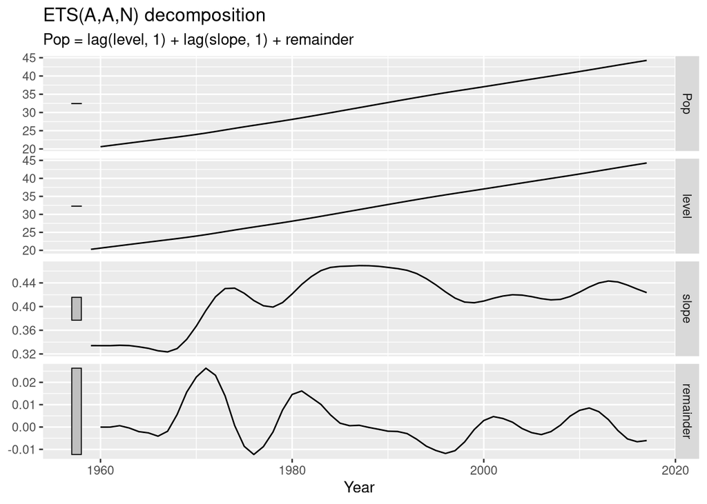

```r
fit |>
  filter(Country == "Argentina") |>
  components() |>
  autoplot()
```

Finally, forecasts for every country at once:

```r
fc <- fit |>
  forecast(h = 5)

fc
```

```
# A fable: 1,315 x 5 [1Y]
# Key:     Country, .model [263]
   Country     .model  Year
   <fct>       <chr>  <dbl>
 1 Afghanistan ets     2018
 2 Afghanistan ets     2019
 3 Afghanistan ets     2020
 4 Afghanistan ets     2021
 5 Afghanistan ets     2022
 6 Albania     ets     2018
 7 Albania     ets     2019
 8 Albania     ets     2020
 9 Albania     ets     2021
10 Albania     ets     2022
# ℹ 1,305 more rows
# ℹ 2 more variables: Pop <dist>, .mean <dbl>
```

# Forecasting with ETS models

The fitted model gives point forecasts and prediction intervals with `forecast()`, as for every model in the course (fpp3 8.7). Australian domestic holiday trips:

```r
aus_holidays <- tourism |>
  filter(Purpose == "Holiday") |>
  summarise(Trips = sum(Trips) / 1e3)

fit <- aus_holidays |>
  model(ETS(Trips))

report(fit)
```

```
Series: Trips
Model: ETS(M,N,A)
  Smoothing parameters:
    alpha = 0.3484054
    gamma = 0.0001000018

  Initial states:
     l[0]       s[0]      s[-1]      s[-2]    s[-3]
 9.727072 -0.5376106 -0.6884343 -0.2933663 1.519411

  sigma^2:  0.0022

     AIC     AICc      BIC
226.2289 227.7845 242.9031
```

`ETS()` chose $ETS(M,N,A)$: multiplicative errors, no trend, additive seasonality. It was a close call:

```r
aus_holidays |>
  model(
    MNA = ETS(Trips ~ error("M") + trend("N") + season("A")),
    MNM = ETS(Trips ~ error("M") + trend("N") + season("M"))
  ) |>
  glance() |>
  select(.model, AICc)
```

```
# A tibble: 2 × 2
  .model  AICc
  <chr>  <dbl>
1 MNA     228.
2 MNM     228.
```

The two seasonal forms are within a fraction of a point of $AIC_c$, and measured in thousands of trips instead of millions (Exercise 2) the choice flips to $ETS(M,N,M)$. When two models are that close, the criterion cannot tell them apart, and either is defensible.

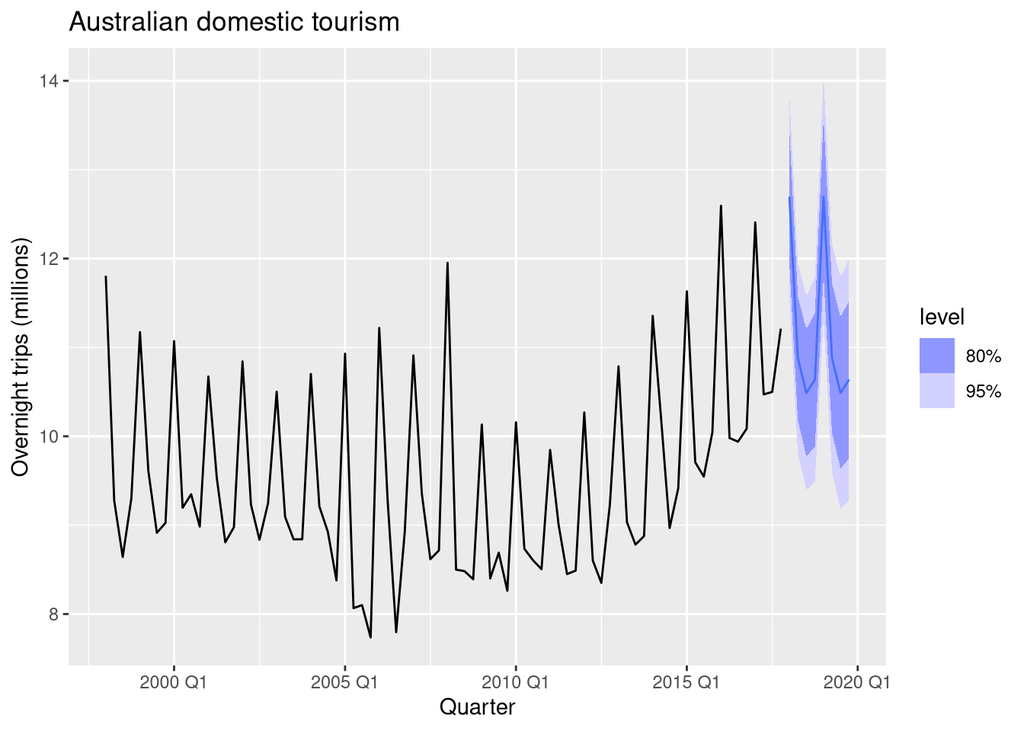

```r
fit |>
  forecast(h = 8) |>
  autoplot(aus_holidays) +
  labs(title = "Australian domestic tourism",
       y = "Overnight trips (millions)")
```

Three points about these forecasts:

- **Point forecasts.** ETS point forecasts are the means of the forecast distributions, except for models with multiplicative seasonality. This model has additive seasonality, so `.mean` is the mean.
- **Intervals.** The prediction intervals differ between models with additive and multiplicative components: with multiplicative errors they widen with the level of the series.
- **How they are computed.** For some ETS models there is no formula for the forecast variance. Then `forecast()` simulates many future paths and takes percentiles of them, the bootstrap idea from Session 12, with simulated errors.

```r
fit |>
  forecast(h = 8) |>
  hilo(level = 95) |>
  head(4)
```

```
# A tsibble: 4 x 5 [1Q]
# Key:       .model [1]
  .model     Quarter
  <chr>        <qtr>
1 ETS(Trips) 2018 Q1
2 ETS(Trips) 2018 Q2
3 ETS(Trips) 2018 Q3
4 ETS(Trips) 2018 Q4
# ℹ 3 more variables: Trips <dist>, .mean <dbl>, `95%` <hilo>
```

# Exercise 1

From the dataset `tourism`, keep the trips with purpose `Holiday`. The result has one series for each combination of `Region` and `State` (check the key of the tsibble).

1. Fit an automatic ETS model to every series, chosen by $AIC_c$.
2. Report the model chosen for the region of Brisbane, and say in one sentence what each of its three letters means for this series.
3. Plot the components of the Brisbane model.
4. Forecast eight quarters for every region, and plot the Brisbane forecasts with the data.

### We’ll discuss potential solutions during the live session.

# Exercise 2

Sum the trips with purpose `Holiday` over all regions, as in the forecasting section above (in thousands of trips this time).

1. Fit an automatic ETS model and report it.
2. Do the response residuals and the innovation residuals match? Check with `all.equal()` and explain why in one sentence.

```r
aus_holidays_total <- tourism |>
  filter(Purpose == "Holiday") |>
  summarise(Trips = sum(Trips))

aus_holidays_total
```

```
# A tsibble: 80 x 2 [1Q]
   Quarter  Trips
     <qtr>  <dbl>
 1 1998 Q1 11806.
 2 1998 Q2  9276.
 3 1998 Q3  8642.
 4 1998 Q4  9300.
 5 1999 Q1 11172.
 6 1999 Q2  9608.
 7 1999 Q3  8914.
 8 1999 Q4  9026.
 9 2000 Q1 11071.
10 2000 Q2  9196.
# ℹ 70 more rows
```

### We’ll discuss potential solutions during the live session.

# Exercise 3

From the dataset `PBS`, keep the prescriptions with `ATC2 == "H02"` (corticosteroids) and sum the cost over all the other keys, month by month.

1. Fit an automatic ETS model and say which model was chosen.
2. Fit $ETS(A,A,A)$ as well, and compare the two by $AIC_c$.
3. Use cross-validation to choose between the two for a one-year-ahead forecast: the smallest training set has 80% of the observations, the sets grow one month at a time, and the forecasts go up to 12 months ahead. Compare the RMSE averaged over the horizons.
4. In one sentence: why can the AICc compare these two models, and when would you need cross-validation instead?

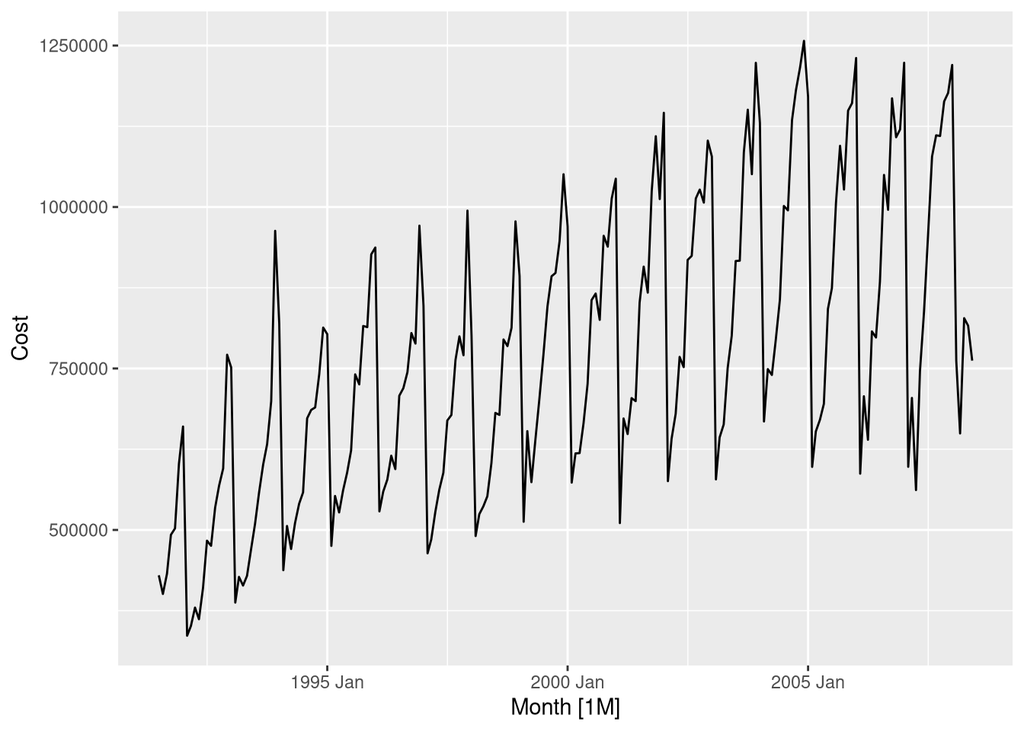

```r
h02 <- PBS |>
  filter(ATC2 == "H02") |>
  summarise(Cost = sum(Cost))

h02 |> autoplot(Cost)
```

### We’ll discuss potential solutions during the live session.